# Groupement hospitalier de territoire (GHT)

JcB

16/01/2017

Comment extaire les GHT de la Région Grand Est (RGE) ? On part des communes de la France Entière. Puis on extrait les communes de la RGE. Ensuite on merge ce fichier avec celui des GHT. On obtient un spatialPolygonDataFrame contenant le contour des communes (polygons) et le GHT d’appartenance.

# Fichiers nécéssaires

IGN_GEOFLA_2016/Fichier_SHP/COMMUNE “~/Downloads/Liste_GrandEst_COM_CodePMSI_GHT_27102016_VF.csv”: liste

Fichier des communes faisant partie de GHT du grand est (transmis par Lagille) ght2 <- read.csv2(“~/Downloads/Liste_GrandEst_COM_CodePMSI_GHT_27102016_VF.csv”)

# Fichiers créés

- ght.Rda: GHT de la région gand est avec les communes
- save(ght3, file = “GHT/limites_des_ght.Rda”)

# Bibliothèques nécessaires

```r
library(sp)
library(rgdal)
```

```r
library(maptools)
source("../Carto_utilitaires.R") # suprimer ../ si console
```

# GHT

```r
# Mac book air
#dsn <- "/Users/jcb/Documents/Cartographie/Donnee_IGN/COMMUNE"

# IMac (fichiers 2015)
# dsn <- "/Users/jean-claudebartier/Documents/CARTOGRAPHIE/CartographieR/IGN_GEOFLA_2015/Fichier_SHP/COMMUNE"

# IMac - fichiers 2016
dsn <- "/Users/jean-claudebartier/Documents/CARTOGRAPHIE/CartographieR/IGN_GEOFLA_2016/COMMUNE"

# carte de France avec toutes les communes
france <- readOGR(dsn = dsn, layer = "COMMUNE")
```

On commmence par charger la carte de France avec toutes les communes pour ne retenir que les communes dela RGE.

```r
# départements de la RGE
dep.rge <-  c("08", "51", "10", "52", "55", "54", "57", "88", "67", "68")

# la fonction add0 ajoute un zero denent un département dontle code est < 10
#dep <- add0(dep)

# Contour des départements RGE
dep <- france[france$CODE_DEPT %in% dep.rge,]
dep <- unionSpatialPolygons(dep, IDs = dep@data$CODE_DEPT)
save(dep, file = "../GHT/contour_departements.Rda")
# le contour des déartements n'est pas suerposable  celui des GHT.
# essayer:
# --------
# plot(ght5) # carte des GHT
# plot(dep, border = "red", lty = 3, add = T) # carte des departements en pointillé rouge
# b <- coordinates(dep) # n° des départements
# text(b, names(dep), col = "red") # affiche le n° du dep.

# ensemble des communes constituant les GHT de la RGE. Liste transmise par E.Lagille
pathGht <- "/Users/jean-claudebartier/Documents/Resural/Stat Resural/RPU_Doc/RPU_Carto-Pop-Alsace/Cartographie/ght_com.csv"
```

```r
ght2 <- read.csv(pathGht)
```

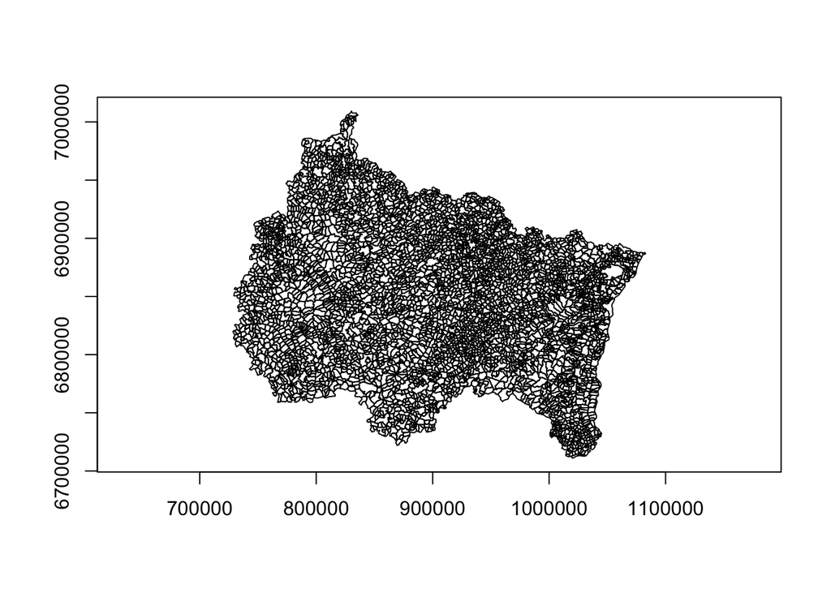

```r
a <- add0(ght2$code_com) # ajoute un 0 devant un Finess trop court
ght2$code_com <- a

# La carte fournie par l'ARS est fausse car le GHT2 englobe les communes des départements 21 et 71 qui ne font pas partie de la région grand est. Il faut donc les éliminer:
ght4 <-ght2[ght2$DEP != 21 & ght2$DEP != 71 ,]
# on met un 0 devant les départements dont le n° est < à 10
x <- add0(ght4$code_com)
ght4$code_com <- x

ght  <- france[france@data$INSEE_COM %in% ght4$code_com,]
plot(ght, axes = TRUE)
```

```r
# carte des GHT (limites avec les comunes)
# ght  <- france[france@data$INSEE_COM %in% ght2$code_com,]
# plot(ght, axes = TRUE)

# on vérfie que la projection est renseignée:
ght@proj4string
```

```
## CRS arguments:
##  +proj=lcc +lat_1=44 +lat_2=49 +lat_0=46.5 +lon_0=3 +x_0=700000
## +y_0=6600000 +ellps=GRS80 +units=m +no_defs
```

```r
save(ght, file = "../GHT/ghtRGE_avecCommunes.Rda")
```

**ght** est la carte des communes de la RGE.

On fait une jointure avec le fichier des GHT

```r
#merging des fichiers
##Jointure utilisant la méthode match qui ne modifi pas l'ordre des lignes
ght2$code_com <- add0(ght2$code_com)
a <- Attrib.Join(ght2, ght, "code_com", "INSEE_COM")
names(a)
```

```
##  [1] "ID_GEOFLA"  "CODE_COM"   "INSEE_COM"  "NOM_COM"    "STATUT"
##  [6] "X_CHF_LIEU" "Y_CHF_LIEU" "X_CENTROID" "Y_CENTROID" "Z_MOYEN"
## [11] "SUPERFICIE" "POPULATION" "CODE_ARR"   "CODE_DEPT"  "NOM_DEPT"
## [16] "CODE_REG"   "NOM_REG"    "code_com"   "code_geo"   "annee"
## [21] "lib_com"    "GHT"        "LIB_GHT"    "DEP"
```

**a** est un spatialPolygonDataFrame => possède un dataFrame et plot(a) dessine les GHT de l’est avec les communes.

NB: si le champ PoPULATION n’est pas transformé en numérique, tapply génère une erreur. Voir: http://stackoverflow.com/questions/18045096/r-error-sum-not-meaningful-for-factors

```r
# Population par GHT
tapply(as.numeric(a$POPULATION), a$GHT, sum)
```

```
##       1       2       3       4       5       6       7       8       9
##  672823 1774203 1323691  918883 1782316 1228365 1645840 1358546  673675
##      10      11      12
## 1596327  672540  717777
```

```r
# Population totale
sum(tapply(as.numeric(a$POPULATION), a$GHT, sum))
```

```
## [1] 14364986
```

```r
# en ¨%
round(100 * tapply(as.numeric(a$POPULATION), a$GHT, sum) / sum(tapply(as.numeric(a$POPULATION), a$GHT, sum)), 2)
```

```
##     1     2     3     4     5     6     7     8     9    10    11    12
##  4.68 12.35  9.21  6.40 12.41  8.55 11.46  9.46  4.69 11.11  4.68  5.00
```

```r
# densité
tapply(as.numeric(a$POPULATION), a$GHT, sum) / tapply(as.numeric(a$SUPERFICIE), a$GHT, sum)
```

```
##         1         2         3         4         5         6         7
## 0.9122170 1.1554645 1.1856749 1.1175254 1.0783864 0.9065130 0.9460406
##         8         9        10        11        12
## 0.9185441 0.9376601 1.1071764 1.1507131 0.9863137
```

```r
# densité au km2
1000 * tapply(as.numeric(a$POPULATION), a$GHT, sum) / tapply(as.numeric(a$SUPERFICIE), a$GHT, sum)
```

```
##         1         2         3         4         5         6         7
##  912.2170 1155.4645 1185.6749 1117.5254 1078.3864  906.5130  946.0406
##         8         9        10        11        12
##  918.5441  937.6601 1107.1764 1150.7131  986.3137
```

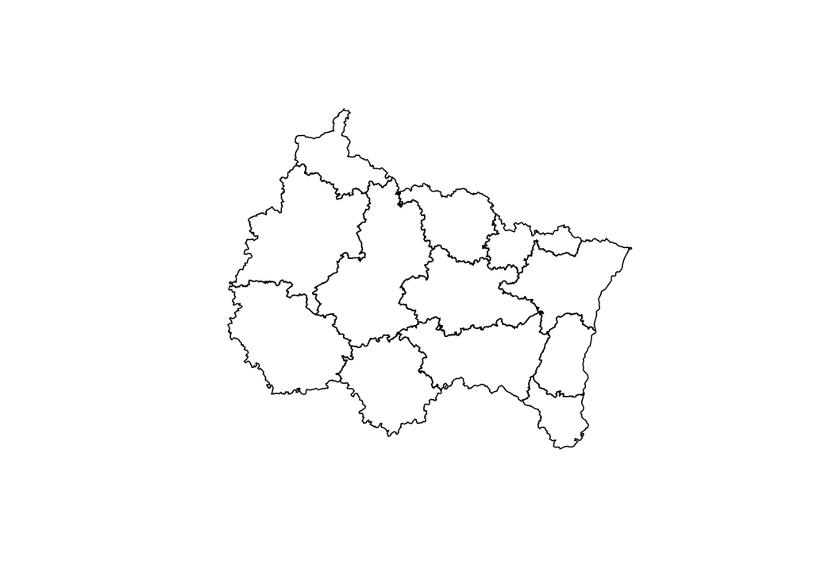

```r
# trace les limites des GHT
ght3 <- unionSpatialPolygons(a, IDs = a@data$GHT)
plot(ght3)
```

```r
save(ght3, file = "../GHT/limites_des_ght.Rda")
```

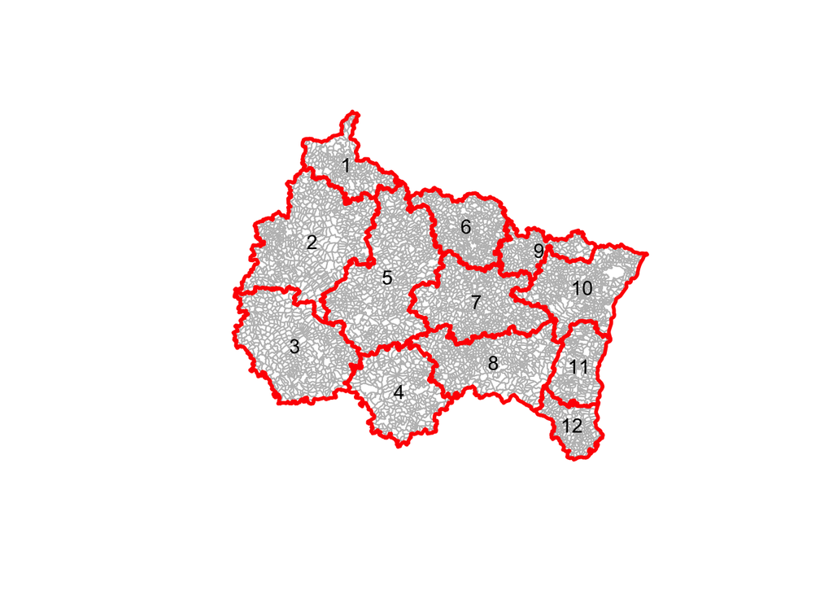

```r
# exemple: dessine les communes et en surimpression les limites des GHT.
plot(a, border = "gray")
plot(ght3, border = "red", lwd = 3, add = TRUE)

# centroïdes des 12 GHT
b <- coordinates(ght3)
text(b, names(ght3))
```

```r
# Détails des slots
c <- sapply(slot(ght3, "polygons"), slot, "area")
d <- sapply(slot(ght3, "polygons"), slot, "ID")
# e <- sapply(slot(GHT3, "polygons"), slot, "labpt")

ght_geo <- rbind(c,d)
ght_geo <- t(ght_geo)
colnames(ght_geo) <- c("surface", "ID")
# tri par n° ID
 ght_geo[order(as.numeric(ght_geo[,2])),]
```

```
##       surface            ID
##  [1,] "2764323461.41728" "1"
##  [2,] "8148687429.20631" "2"
##  [3,] "7100805711.95334" "3"
##  [4,] "4860261233.2451"  "4"
##  [5,] "8411232269.96513" "5"
##  [6,] "3563420129.9844"  "6"
##  [7,] "5483992182.12344" "7"
##  [8,] "5891297313.82179" "8"
##  [9,] "2076550794.58396" "9"
## [10,] "4960296259.28506" "10"
## [11,] "2605379996.44195" "11"
## [12,] "1837472060.45918" "12"
```

```r
#tri par surface
ght_geo[order(as.numeric(ght_geo[,1])),]
```

```
##       surface            ID
##  [1,] "1837472060.45918" "12"
##  [2,] "2076550794.58396" "9"
##  [3,] "2605379996.44195" "11"
##  [4,] "2764323461.41728" "1"
##  [5,] "3563420129.9844"  "6"
##  [6,] "4860261233.2451"  "4"
##  [7,] "4960296259.28506" "10"
##  [8,] "5483992182.12344" "7"
##  [9,] "5891297313.82179" "8"
## [10,] "7100805711.95334" "3"
## [11,] "8148687429.20631" "2"
## [12,] "8411232269.96513" "5"
```

On peut en déduire le plus grand, le plus petit…

# en couleur

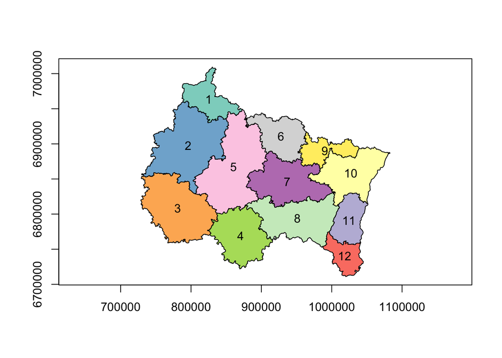

```r
library(RColorBrewer)
coul <- brewer.pal(n=12, name = "Set3")
ght <- unionSpatialPolygons(a, IDs = a@data$GHT)
plot(ght, col = coul, axes = TRUE)
b <- coordinates(ght)
text(b, names(ght))
```

# Représentation par GHT

## Exemple GHT n°1

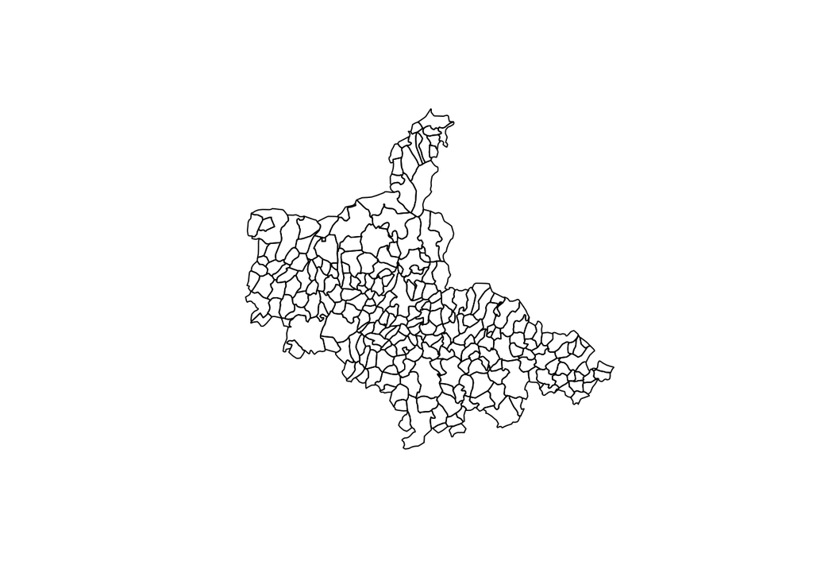

```r
ght1 <- a[a@data$GHT == 1,]
plot(ght1)
```

```r
ght01 <- unionSpatialPolygons(ght1, ght1@data$GHT == 1)
plot(ght01, main = "GHT n°1", axes = T)

# préfecture
ght1@data[which(ght1@data$STATUT == "Préfecture de département"),]
```

```
##                      ID_GEOFLA CODE_COM INSEE_COM              NOM_COM
## 26869 COMMUNE00000000000026870      105     08105 CHARLEVILLE-MEZIERES
##                          STATUT X_CHF_LIEU Y_CHF_LIEU X_CENTROID
## 26869 Préfecture de département     823973    6963698     823082
##       Y_CENTROID Z_MOYEN SUPERFICIE POPULATION CODE_ARR CODE_DEPT NOM_DEPT
## 26869    6966367     183       3177      48991        1        08 ARDENNES
##       CODE_REG                           NOM_REG code_com code_geo annee
## 26869       44 ALSACE-CHAMPAGNE-ARDENNE-LORRAINE    08105     8000  2015
##                    lib_com GHT                LIB_GHT DEP
## 26869 CHARLEVILLE MEZIERES   1 01 - GHT Nord Ardennes   8
```

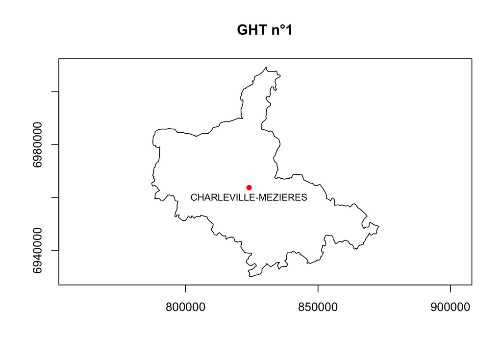

```r
x <- ght1@data[which(ght1@data$STATUT == "Préfecture de département"),]$X_CHF_LIEU
y <- ght1@data[which(ght1@data$STATUT == "Préfecture de département"),]$Y_CHF_LIEU
points(x,y, pch = 16, col = "red")
text(x,y, ght1@data[which(ght1@data$STATUT == "Préfecture de département"),]$NOM_COM, pos = 1, cex = 0.8)
```

# Hôpitaux-SU de la région grand est

On récupère les fichiers correspondants dans le dossier **/Users/jean-claudebartier/Documents/Resural/Stat Resural/RPU_Doc/RPU_Carto-Pop-Alsace/Cartographie/Structures_Urgence_FEDorU**. Il y a 3 fichiers au format csv correspondant aux anciennes régions.

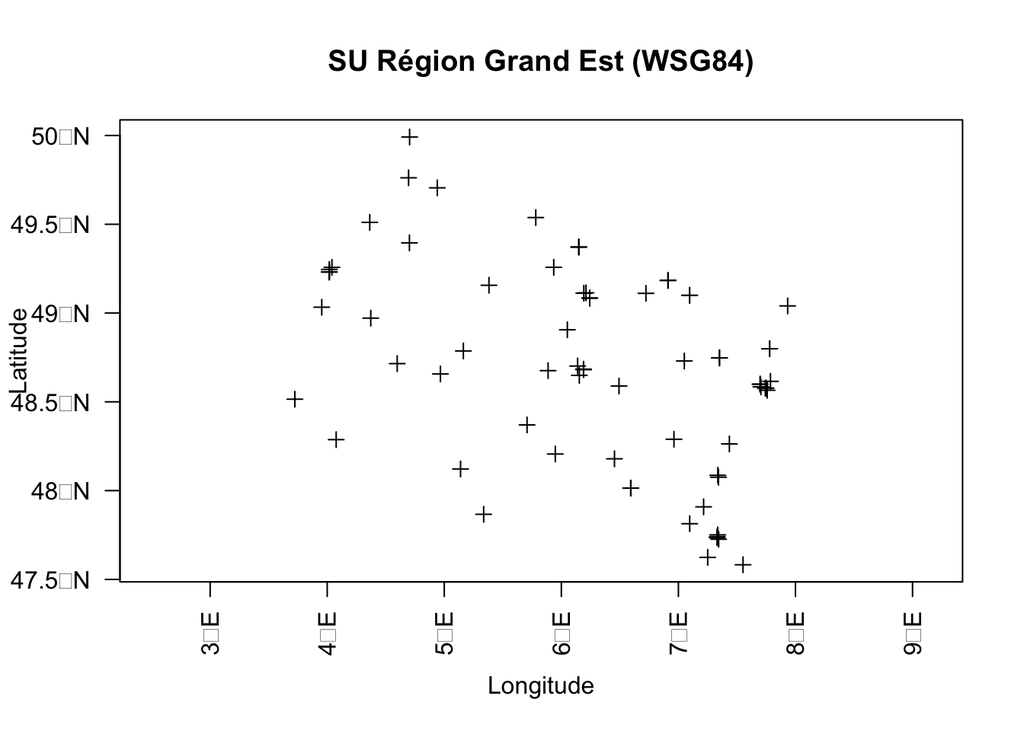

```r
path = "/Users/jean-claudebartier/Documents/Resural/Stat Resural/RPU_Doc/RPU_Carto-Pop-Alsace/Cartographie/Structures_Urgence_FEDorU/"
a <- paste0(path, "Structures d'urgence_Als.csv")
b <- paste0(path, "Structures d'urgence_Lor.csv")
c <- paste0(path, "Structures d'urgence_CA.csv")

a2<-read.csv(a, skip = 1)
b2<-read.csv(b, skip = 1)
c2<-read.csv(c, skip = 1)
hopRge <- rbind(a2,b2,c2)
# On ne cnserve que les colonnes ayant un intéret. Les col. 12 et 13 contiennent latitude et longitude en WS84.
hopRge <- hopRge[, c(2,3,7,8,9,10,15,16,20,21)]

d2 <- hopRge
# on transforme mes virgules en points puis en numéric
d2$Longitude <- as.numeric(gsub(",",".", d2$Longitude))
d2$Latitude <- as.numeric(gsub(",",".", d2$Latitude))

coordinates(d2) = ~ Longitude + Latitude
proj4string(d2) = CRS("+proj=longlat +datum=WGS84")

plot(d2, xlab = "Longitude", ylab = "Latitude", axes = TRUE, las = 2, main = "SU Région Grand Est (WSG84)")
```

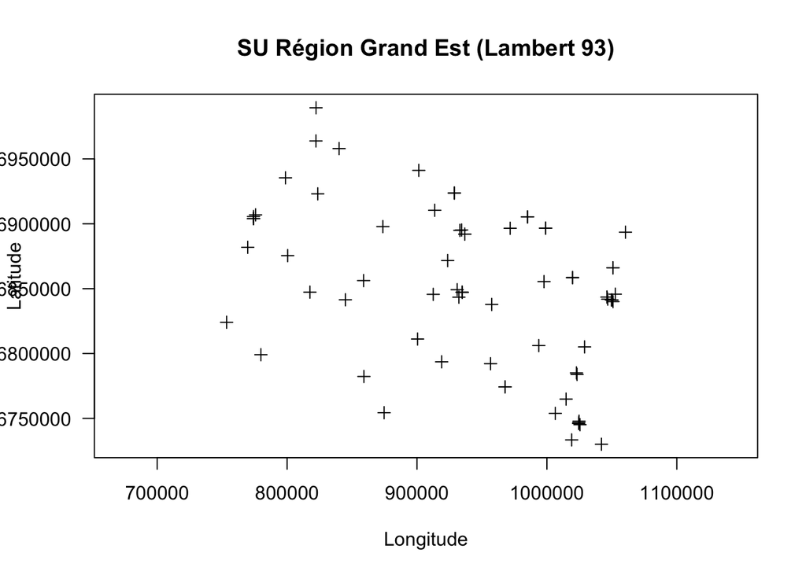

```r
# Reprojeter au format Lambert 93
# -------------------------------
# EPSG:2154 Lambert 93
newProj = CRS("+proj=lcc +lat_1=49 +lat_2=44 +lat_0=46.5 +lon_0=3 +x_0=700000 +y_0=6600000 +ellps=GRS80 +towgs84=0,0,0,0,0,0,0 +units=m +no_defs")
su_alca_L93 <- spTransform(d2, newProj)
plot(su_alca_L93, xlab = "Longitude", ylab = "Latitude", axes = TRUE, las = 1, main = "SU Région Grand Est (Lambert 93)")
```

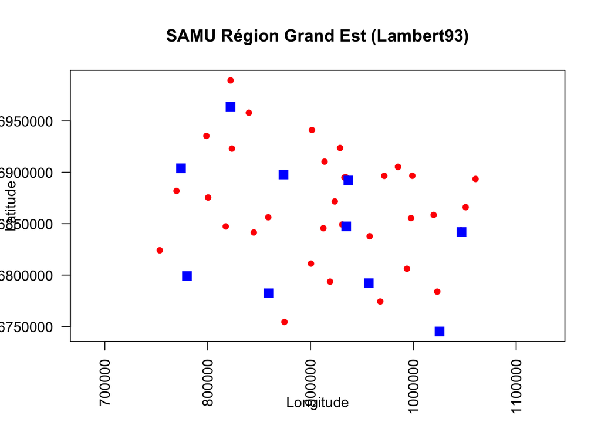

```r
plot(su_alca_L93[su_alca_L93$SMUR == "oui",], pch = 16, col = "red", xlab = "Longitude", ylab = "Latitude", axes = TRUE, las = 2, main = "SAMU Région Grand Est (Lambert93)")

plot(su_alca_L93[su_alca_L93$SAMU == "oui",], pch = 15, col = "blue", xlab = "Longitude", ylab = "Latitude", axes = TRUE, las = 2, main = "SAMU Région Grand Est (Lambert93)", cex = 1.5, add = TRUE)
```